# Python for Finance Primer

Prof. Daniel P. Palomar

Python code: [Zé Vinícius](https://github.com/mirca) IEDA/ELEC3180 - Data-Driven Portfolio Optimization The Hong Kong University of Science and Technology (HKUST) Spring 2022-23

This Python session will introduce the basics of Python for finance.

# Introduction

## What is Python?

- Python is a general purpose, high-level, interpreted language that has become one of the *de facto* tools for data science, data analysis, machine learning, and finance. For instance, Python has topped the [IEEE rank of top programming languages](https://spectrum.ieee.org/computing/software/the-top-programming-languages-2019) for many years in a row.
- Python was created by Guido van Rossum in 1991. Guido acted as Python’s Benevolent Dictator for Life (BDFL) and rencently retired as a Principal Engineer from Dropbox. Python’s main philosophy focuses on code readability, i.e., it provides a simple, easy-to-follow grammar, which often translates into rapid code development.
- Python is an actively developed open source language. The Python Software Foundation (PSF) holds the intellectual property rights and protects the trademarks associated with Python. Agencies, foundations, private companies, and non-profit organizations support the development of Python and many of its open source libraries. Just to name a few, the Moore Foundation, the NumFOCUS organization, Microsoft, J.P. Morgan, and so on, have been funding the development of Python for many years.
- Python is distributed by a variety of sources of which we recommend the Anaconda Python primarily due to its straightforward installation procedure.
- Useful Python links:
  - [Anaconda](https://www.anaconda.com/distribution/)
  - Searching packages: [PYPI](https://pypi.org/)
  - [Python documentation](https://docs.python.org/3/)
  - [JupyterLab](https://jupyterlab.readthedocs.io/en/stable/) is the *de facto* environment for data analysis
  - Learning: [LearnPython](https://www.learnpython.org/), [Python for Beginners](https://www.python.org/about/gettingstarted/), [Learn Python 3](https://www.codecademy.com/learn/learn-python-3), [The Hitchhiker’s Guide to Python](https://docs.python-guide.org/intro/learning/), [NumPy basics by Andrej Karpathy](http://cs231n.github.io/python-numpy-tutorial/#numpy), [Matplotlib basics](https://matplotlib.org/tutorials/introductory/pyplot.html), [Seaborn basics](https://seaborn.pydata.org/introduction.html), [Pandas Crash Course by Datacamp](https://www.datacamp.com/community/blog/python-pandas-cheat-sheet),
  - [Stack Overflow](https://stackoverflow.com/questions/tagged/python)
  - [Python homepage](https://www.python.org)
  - Other resources: [Book: Python for Finance, mastering data-driven finance](https://python-for-finance.com/static/yjh_py4fi_2nd_excerpt.pdf)

## R vs Python

Let’s not even get started :) Both are great! Learn both! You’ll have to use whatever your boss/advisor/team needs. But don’t forget to know a bit of C++ too :)

## Installation

Install the Python distribution from [Ananconda](https://www.anaconda.com/distribution/#download-section).

To get started coding, [start the Jupyter Notebook app](https://jupyter-notebook-beginner-guide.readthedocs.io/en/latest/execute.html) by clicking on the Jupyter Notebook icon or by openning a terminal (or *cmd* on Windows) and typing `jupyter notebook`. Alternatively, one can use Jupyter lab by openning a terminal (or *cmd* on Windows) and typing `jupyter lab`. A browser window should pop up where you can navigate to `File` >> `New` >> `Notebook`. A Jupyter Notebook is an environment where you can write code and interactively evaluate its output. This feature is very convenient for exploratory analysis. Now you are ready to start using Python from within JupyterLab (note that you can also use Python directly from the command line without the need for JupyterLab or you can use another IDE of your preference like [PyCharm](https://www.jetbrains.com/pycharm/)).

## Packages

To see the versions of Python and the installed packages just type `!conda list` on a Jupyter notebook and press SHIFT+ENTER.

To see the version of a specific package use `import package_name; print(package_name.__version__)`.

As time progresses, you will have to install different packages from PYPI or Conda with the command `pip install package_name` or `conda install package_name`. Note that you can execute these commands from within a Jupyter notebook by prepending them with an exclamation mark (`!`).

After installing a package, it needs to be imported before it can be used with the command `import package_name`:

```python
# let's try to use the function mean() from the package numpy:
x = [1, 2, 3]
y = numpy.mean(x)
#> NameError: name 'numpy' is not defined
```

```python
# we need first to import it and use it:
import numpy  # to install: pip install numpy
x = [1, 2, 3]
y = numpy.mean(x)
y
#> 2.0
```

It is common to use shortcuts for the names of the imported libraries:

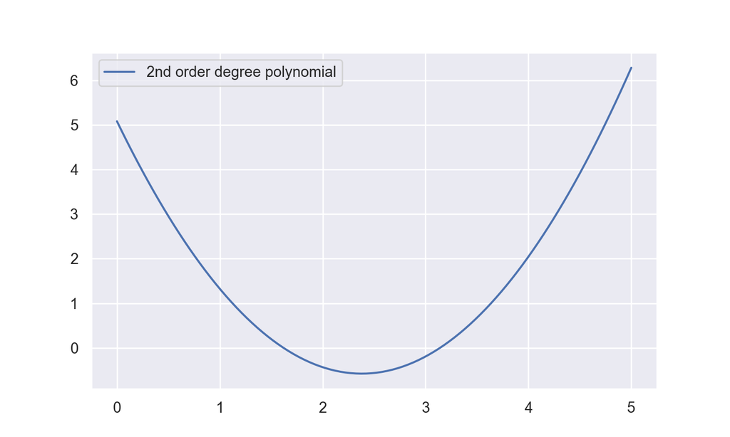

```python
import numpy as np
import matplotlib.pyplot as plt

x = np.linspace(0, 5, 100)
y = (x - np.pi) * (x - 1.618)
plt.plot(x, y, label = "2nd order degree polynomial")
plt.legend()
plt.show()
```

## Variables: lists, dicts, nd-arrays, and data frames

In Python, we can easily assign a value to a variable or object with `=` (if the variable does not exist it will be created):

```python
x = "Hello"
x
#> 'Hello'
```

We can combine several elements with lists:

```python
y = ["Hello", "everyone"]
y
#> ['Hello', 'everyone']
```

Note that elements in a list need not have the same datatype (we’ll see the datatypes in a few minutes)

```python
y = [1, "hello", 2., "everyone"]
y
#> [1, 'hello', 2.0, 'everyone']
```

A dictionary, or simply “dict”, is a data structure that allows mappings between keywords and values. There are many ways to create a dict, the simplest one is just to use curly brackets `{}` as follows:

```python
x = {'a': 1, 'b': 2, 'c': 3}
x
#> {'a': 1, 'b': 2, 'c': 3}
```

Another way is to explicitly specify the keywords and values:

```python
x = dict(a = 1, b = 2, c = 3)
x
#> {'a': 1, 'b': 2, 'c': 3}
```

A dict can store different data types for different keywords:

```python
x = dict(a = '1', b = 2, c = 3)
x
#> {'a': '1', 'b': 2, 'c': 3}
```

The usual way to query a value from a dict is to pass the desired keyword:

```python
x['a']
#> '1'
```

We can also modify the contents of dicts or add new entries:

```python
x = dict(a = 1, b = 2, c = 3)
x['a'] = 2
x
#> {'a': 2, 'b': 2, 'c': 3}
x['d'] = 10
x
#> {'a': 2, 'b': 2, 'c': 3, 'd': 10}
```

Sets in Python are a collection of unordered unique elements. The main purposes of sets are to verify membership, remove duplicate elements from a sequence, and computing standard math operations on sets.

We can create sets from lists as follows:

```python
x = set([1, 2, 3, 1])
x
#> {1, 2, 3}
y = set([2, 4, 5, 3])
y
#> {2, 3, 4, 5}
x.intersection(y)
#> {2, 3}
x.difference(y)
#> {1}
x.symmetric_difference(y)
#> {1, 4, 5}
```

A useful command is `?variable`. It gives you various information about the variable, i.e., type, dimensions, contents, etc. Note that this is a feature only in [IPython](https://ipython.org) and [JupyterLab/Notebook](https://jupyter.org).

Another useful feature in Python is slicing. It is specially good for arrays or lists of large dimensions, showing you the first and last `n` elements, respectively.

```python
x = np.arange(1000)
x[:10]
#> array([0, 1, 2, 3, 4, 5, 6, 7, 8, 9])
x[-10:]
#> array([990, 991, 992, 993, 994, 995, 996, 997, 998, 999])
```

It is important to keep in mind that in Python almost everything is done through functions or methods of all sorts such as `max()`, `min()`, `arange()`, `linspace()`, and so on.

### Data types

Operators in Python: arithmetic operators include `+, -, *, /, **` for addition, subtraction, multiplication, division, and exponentiation. Binary comparison operators are `>, >=, ==, !=`. Boolean operators are `and`, `or`, and their bitwise versions are `&`, `|`.

Python has a wide variety of data types including scalars (float, double, and integers), complex numbers, strings, lists, tuples, dictionaries (dicts), sets, nd-arrays, and data frames.

#### Scalars and strings

Scalars are basically float and integers, for example:

```python
x = 1
type(x)
#> <class 'int'>
x = 1.1
type(x)
#> <class 'float'>
```

Can you think about why Python gives the following answer to the sum `3.3 - (1.1 + 2.2)`?

```python
x = 3.3 - (1.1 + 2.2)
x
#> -4.440892098500626e-16
```

Try the same thing in R and MATLAB. what do you see? Is it different from what Python computed? What is the binary expansion of `0.333333...`? How do computers represent anything? :)

Strings are defined using `""` embracing the characters, e.g.

```python
x = "Hello IEDA/ELEC 3180"
x
#> 'Hello IEDA/ELEC 3180'
```

Complex numbers are defined by using the object `aj`, where `a` is any float or integer number, which represents $a\sqrt{-1}$:

```python
x = 1 + 2j
x
#> (1+2j)
x.conjugate()
#> (1-2j)
x.real
#> 1.0
x.imag
#> 2.0
abs(x)
#> 2.23606797749979
```

Note that the function `abs`, which in case of scalars computes the absolute value, calculates the length of a complex number as it were a vector in $\mathbb{R}^2$.

#### Lists

The most basic data structure in Python is a list. It is an ordered collection of variables of any type defined with squared brackets `[]`. For example:

```python
x = [1, 2, 3., "hello", True]
```

Unlike `R`, `MATLAB`, and `Julia`, Python is 0-index based, which means that `x[0]` is the actual first element of the list `x`. The length of a list may be obtained via the function `len()`.

```python
len(x)
#> 5
```

To access the value in a given position of a list, use indexes:

```python
x[1]  # 2nd element of the list x
#> 2
```

Python allows for negative indexes to be given, e.g., `x[-1]` returns the last item of a list, `x[-2]` returns the second last item, and so on:

```python
x[-1]
#> True
x[-2]
#> 'hello'
```

Additionally, we can retrieve sublists of a list by using slices, e.g., `x[1:3]` returns a sublist containing the elements `x[1]` and `x[2]`; `x[1:]` returns a sublist containing all the elements to the right of (and including) `x[1]`; `x[:3]` returns a sublist containing all the elements to the left of `x[3]`. In general, `x[a:b]`, for integers `a`,`b`, `b > a`, returns the ordered sublist from `x[a]` to `x[b-1]`.

However, in many cases we would like to retrieve a sublist such that the indexes posses a particular property. In the Python jargon this is called “list comprehension”. For instance, let’s retrieve the sublist of elements which are in even positions of the original list `x`:

```python
y = [x[i] for i in range(len(x)) if i % 2 == 0]
y
#> [1, 3.0, True]
```

We can concatenate lists by using the “+” operator:

```python
[1, 2, 3] + [3, 2, 1]
#> [1, 2, 3, 3, 2, 1]
```

#### NumPy arrays

Python was not designed specificaly for scientific computing, however libraries such as [NumPy](https://numpy.org), started by [Travis Oliphant](https://en.wikipedia.org/wiki/Travis_Oliphant), extend the language data structures so as to deal more easily with vectors, matrices, and the mathematical operations involved.

Note that in Python, 1d numpy arrays (or simply 1d-arrays) are not column vectors or row vectors, they do not have any orientation. If one desires a column vector, then that is actually an $n\times 1$ matrix.

It is also important to differentiate elementwise multiplication `*` from inner or dot product `@` (also `np.dot()`):

```python
x = np.array([1, 2])
y = np.array([10, 20])
z = x.reshape((len(x), 1))
x * y
#> array([10, 40])
x @ y
#> 50
z @ np.transpose(z)
#> array([[1, 2],
#>        [2, 4]])
```

Outer product between two arrays can be done via the function `np.outer`:

```python
x = np.array([1, 2])
np.outer(x, x)
#> array([[1, 2],
#>        [2, 4]])
```

The number of elements of a numpy array can be retrieved via `len`:

```python
y = np.array([10, 20])
len(y)
#> 2
```

Be careful when using `len` with arrays with more than one dimension! `len` always return the “size” of the first dimension:

```python
y = np.array([1, 2]).reshape((2, 1))
len(y)
#> 2
len(np.transpose(y))
#> 1
```

#### Matrices

A matrix is two-dimensional collection of several variables of the same type.

We can easily create a matrix with `np.array`:

```python
# generate 5 x 4 numeric matrix
x = np.random.uniform(size=20).reshape((5, 4))
x
# we can get the dimensions or number of rows/columns
#> array([[0.04658426, 0.06387163, 0.59140398, 0.14847519],
#>        [0.38477057, 0.58504561, 0.7989437 , 0.61507112],
#>        [0.47354615, 0.2989456 , 0.06559021, 0.11170894],
#>        [0.49667179, 0.23565342, 0.1787619 , 0.73258516],
#>        [0.6920763 , 0.06720663, 0.00767567, 0.02643388]])
np.shape(x)
#> (5, 4)
```

Identify rows, columns or elements using subscripts:

```python
x[:,3]  # 4th column of matrix (returned as an 1D-array)
#> array([0.14847519, 0.61507112, 0.11170894, 0.73258516, 0.02643388])
x[2,:]  # 3rd row of matrix (returned as an 1D-array)
#> array([0.47354615, 0.2989456 , 0.06559021, 0.11170894])
```

#### Pandas Data frames

Pandas is a data analysis library, started by [Wes McKinney](https://en.wikipedia.org/wiki/Wes_McKinney), whose main data structure is the so called Pandas Data Frames. The basic unit of Pandas dataframes is the Series class. Basically, a dataframe is a collection of column stacked Series objects that share the same “index”. In finance, that “index” usually corresponds to time data (seconds, minutes, hours, days, weeks, months, etc).

A Pandas data frame is more general than numpy nd-arrays in the sense that we can attach labels to columns and have them with different data types

```python
import pandas as pd
df = pd.DataFrame({'float': [1., 2., 3.],
                   'int': [1, 2, 3],
                   'datetime': [pd.Timestamp('20180310'), pd.Timestamp('20190310'), pd.Timestamp('20200310')],
                   'string': ['foo', 'bar', 'buzz']})
df
#>    float  int   datetime string
#> 0    1.0    1 2018-03-10    foo
#> 1    2.0    2 2019-03-10    bar
#> 2    3.0    3 2020-03-10   buzz
```

Let’s check the type of one of the variables:

```python
type(df['float'])
#> <class 'pandas.core.series.Series'>
```

There are a variety of ways to retrieve the elements of a data frame:

```python
df['float']
#> 0    1.0
#> 1    2.0
#> 2    3.0
#> Name: float, dtype: float64
df['float'][0]
#> 1.0
df['datetime']
#> 0   2018-03-10
#> 1   2019-03-10
#> 2   2020-03-10
#> Name: datetime, dtype: datetime64[ns]
df['datetime'][2]
#> Timestamp('2020-03-10 00:00:00')
df.at[1, 'float']
#> 2.0
df.loc[1]
#> float                       2.0
#> int                           2
#> datetime    2019-03-10 00:00:00
#> string                      bar
#> Name: 1, dtype: object
```

We can also set values provided that they can be castable to the type of the column:

```python
df.at[1, 'float'] = 10
df
#>    float  int   datetime string
#> 0    1.0    1 2018-03-10    foo
#> 1   10.0    2 2019-03-10    bar
#> 2    3.0    3 2020-03-10   buzz
```

The variable (column) names can be retrieved via the `.columns` attribute:

```python
df.columns
#> Index(['float', 'int', 'datetime', 'string'], dtype='object')
```

A few other useful methods to inspect dataframes are `head()` and `tail()` that show the first and last few rows (observations) in a dataframe:

```python
df.head(n=1)
#>    float  int   datetime string
#> 0    1.0    1 2018-03-10    foo
df.tail(n=1)
#>    float  int   datetime string
#> 2    3.0    3 2020-03-10   buzz
```

In finance, often times data comes with missing values, usually labeled as “NaN” (not a number) or “NaT” (not a time, for time values). Let’s check out a basic example:

```python
import pandas as pd
import numpy as np

df = pd.DataFrame({"name": ['Superman', 'Batman', 'Spiderman'],
                   "toy": [np.nan, 'Batmobile', 'Spiderman toy'],
                   "born": [pd.NaT, pd.Timestamp("1956-06-26"),
                            pd.NaT]})
df
#>         name            toy       born
#> 0   Superman            NaN        NaT
#> 1     Batman      Batmobile 1956-06-26
#> 2  Spiderman  Spiderman toy        NaT
```

Now, in case we simply would like to remove the rows (observations) where at least one element is NaN or NaT, we use `df.dropna()`:

```python
df.dropna()
#>      name        toy       born
#> 1  Batman  Batmobile 1956-06-26
```

In case we would like to remove the columns (variables) where at least one element is missing, we make use of the argument `axis`:

```python
df.dropna(axis='columns')
#>         name
#> 0   Superman
#> 1     Batman
#> 2  Spiderman
```

Many other options are available to deal with NaNs and NaTs, such as specifying which columns to look for missing values:

```python
df.dropna(subset=['name', 'born'])
#>      name        toy       born
#> 1  Batman  Batmobile 1956-06-26
```

Note that this operations do not happen in place, i.e., the original dataframe is kept intact. In case we would like to perform in place modifications, we use the argument `inplace=True`:

```python
df
#>         name            toy       born
#> 0   Superman            NaN        NaT
#> 1     Batman      Batmobile 1956-06-26
#> 2  Spiderman  Spiderman toy        NaT
df.dropna(inplace=True)
df
#>      name        toy       born
#> 1  Batman  Batmobile 1956-06-26
```

Data frames in Python are very powerful and versatile. They are commonly used in machine learning where each row is one observation and each column one variable (each variable can be of different types). For financial applications, we mainly deal with multivariate time series, which can be seen as a matrix or data frame, but with some particularities: each row is an observation but in a specific order (properly indexed with dates or times) and each column is of the same time (double).

## Plotting

We will make full use of [Matplotlib](https://matplotlib.org), [Seaborn](https://seaborn.pydata.org), and [Plotly](https://plot.ly/python/time-series/#time-series-plot-with-datetime-objects) for all our plots :) See the example below for how to plot data stored in a Pandas dataframe with `seaborn`.

Let’s examine this code snippet from [matplotlib’s documentation page](https://matplotlib.org/gallery/lines_bars_and_markers/scatter_demo2.html)

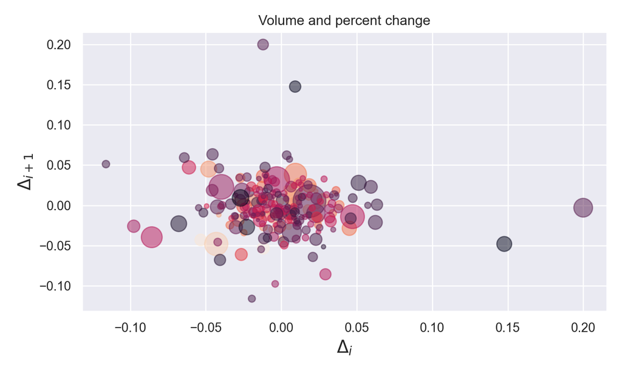

```python
import numpy as np
import matplotlib.pyplot as plt
import matplotlib.cbook as cbook  # to install: conda install -c conda-forge mpl_sample_data

# Load a numpy record array from yahoo csv data with fields date, open, close,
# volume, adj_close from the mpl-data/example directory. The record array
# stores the date as an np.datetime64 with a day unit ('D') in the date column.
datafile = cbook.get_sample_data('goog.npz')
price_data = np.load(datafile)['price_data'].view(np.recarray)
datafile.close()
price_data = price_data[-250:]  # get the most recent 250 trading days
type(price_data)
#> <class 'numpy.recarray'>
delta1 = np.diff(price_data.adj_close) / price_data.adj_close[:-1]
# Marker size in units of points^2
volume = (15 * price_data.volume[:-2] / price_data.volume[0])**2
close = 0.003 * price_data.close[:-2] / 0.003 * price_data.open[:-2]
fig, ax = plt.subplots()
ax.scatter(delta1[:-1], delta1[1:], c=close, s=volume, alpha=0.5)
ax.set_xlabel(r'$\Delta_i$', fontsize=15)
ax.set_ylabel(r'$\Delta_{i+1}$', fontsize=15)
ax.set_title('Volume and percent change')
ax.grid(True)
fig.tight_layout()
plt.show()
```

Matplotlib basically deals with numpy nd-arrays and its subclasses like `np.recarray` used in the previous example. Seaborn, on the other hand, can deal with Pandas DataFrames too. Let’s see a basic example from [seaborn’s documentation page](https://seaborn.pydata.org/introduction.html):

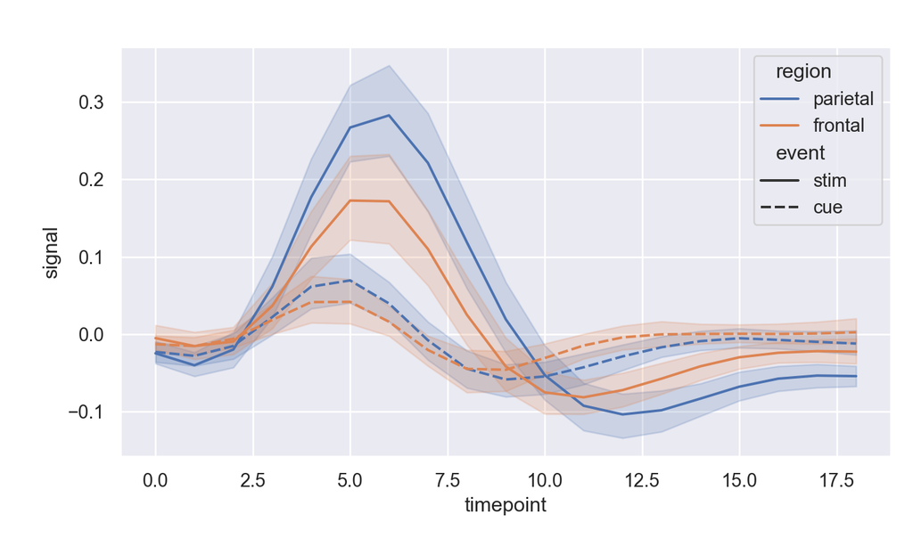

```python
import seaborn as sns
sns.set(style="darkgrid")
# Load an example dataset with long-form data
fmri = sns.load_dataset("fmri")
print(type(fmri))
#> <class 'pandas.core.frame.DataFrame'>
print(fmri.head())
# Plot the responses for different events and regions
#>   subject  timepoint event    region    signal
#> 0     s13         18  stim  parietal -0.017552
#> 1      s5         14  stim  parietal -0.080883
#> 2     s12         18  stim  parietal -0.081033
#> 3     s11         18  stim  parietal -0.046134
#> 4     s10         18  stim  parietal -0.037970
sns.lineplot(x="timepoint", y="signal",
             hue="region", style="event",
             data=fmri)
```

# Key packages for finance

We will make use of several key libraries in Python

## Package [**pandas_datareader**](https://pandas-datareader.readthedocs.io/en/latest/)

The package **pandas_datareader** let us query financial data from different sources readily as Pandas dataframes.

Let’s see how to get Apple stock price data from Yahoo! Finance with the `pandas_datareader` package:

```r
# Load data with R since Python fails
library(quantmod)
apple <- getSymbols("AAPL", from = "2014-01-01", to = "2016-12-31", auto.assign = FALSE)
apple <- as.data.frame(apple[, c("AAPL.High", "AAPL.Low", "AAPL.Open", "AAPL.Close", "AAPL.Adjusted")])
names(apple) <- c('High', 'Low', 'Open', 'Close', 'Adj Close')
```

```python
# import pandas_datareader as pdr  # pip install pandas_datareader
# apple = pdr.get_data_yahoo('AAPL')
apple = r.apple  # get data from R since Python fails to load it with package pandas_datareader
```

Now, let’s inspect the Pandas dataframe `apple` via methods such as `head()`, `tail()`, that show the first and last few observations of the dataframe

```python
apple.head()
#>                  High        Low       Open      Close  Adj Close
#> 2014-01-02  19.893929  19.715000  19.845715  19.754642  17.415539
#> 2014-01-03  19.775000  19.301071  19.745001  19.320715  17.032982
#> 2014-01-06  19.528570  19.057142  19.194643  19.426071  17.125864
#> 2014-01-07  19.498571  19.211430  19.440001  19.287144  17.003391
#> 2014-01-08  19.484285  19.238930  19.243214  19.409286  17.111067
apple.tail()
#>                  High        Low       Open      Close  Adj Close
#> 2016-12-23  29.129999  28.897499  28.897499  29.129999  27.261320
#> 2016-12-27  29.450001  29.122499  29.129999  29.315001  27.434456
#> 2016-12-28  29.504999  29.049999  29.379999  29.190001  27.317472
#> 2016-12-29  29.277500  29.100000  29.112499  29.182501  27.310457
#> 2016-12-30  29.299999  28.857500  29.162500  28.955000  27.097544
```

We can also plot the some desired columns of a dataframe using the `plot()` method:

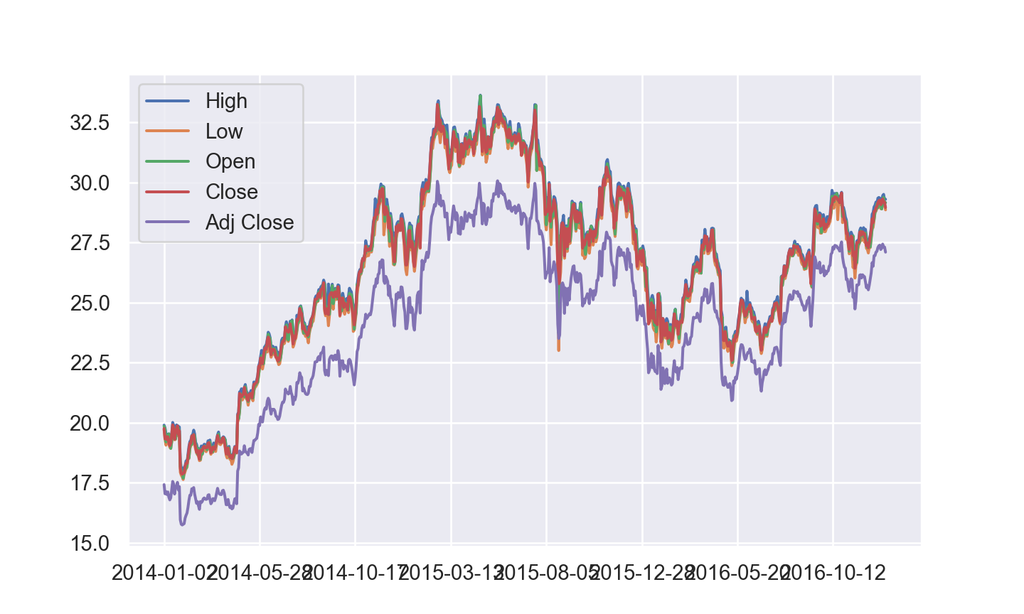

```python
apple[['High', 'Low', 'Open', 'Close', 'Adj Close']].plot()
```

You can install `pandas_datareader` via `PyPI` by typing `! pip install pandas_datareader` on a Jupyter notebook or `pip install pandas_datareader` in a terminal.

## Package [**yfinance**](https://github.com/ranaroussi/yfinance)

The package **yfinance** let us query financial instruments data from the Yahoo! Finance platform.

The syntax is similar to `pandas_datareader`:

```python
import yfinance as yf  # pip install yfinance
tickers = "AAPL"
data = yf.download(tickers, start="2017-01-01", end="2017-04-30")
```

In addition, we can speed up our `pandas_datareader` queries for free by doing:

```python
import yfinance as yf
yf.pdr_override()
```

## Package [**empyrical**](https://quantopian.github.io/empyrical/)

The empyrical package is an open source Python package developed by Quantopian Inc. It’s widely used by practitioners to compute common risk and performance measures.

```python
from empyrical import max_drawdown, roll_max_drawdown, cum_returns, omega_ratio, sharpe_ratio  # pip install empyrical
# create a synthetic array of returns
returns = np.array([.01, .02, .03, -.4, -.06, -.02])
max_drawdown(returns)  # calculate the maximum drawdown
#> -0.4472800000000001
roll_max_drawdown(returns, window=3) # calculate the maximum drawdown in a rolling window fashion
#> array([ 0.     , -0.4    , -0.436  , -0.44728])
cum_returns(returns) # calculate the cumulative returns
#> array([ 0.01      ,  0.0302    ,  0.061106  , -0.3633364 , -0.40153622,
#>        -0.41350549])
omega_ratio(returns) # calculate the Omega ratio
#> 0.12499999999999999
sharpe_ratio(returns) # calculate the Sharpe ratio
#> -6.7377339531573535
```

## Package [**riskparity.py**](https://mirca.github.io/riskparity.py)

**riskparity.py** is a package to design risk parity portfolios, a different approach to investment that is primarily used to control how much risk goes into each asset.

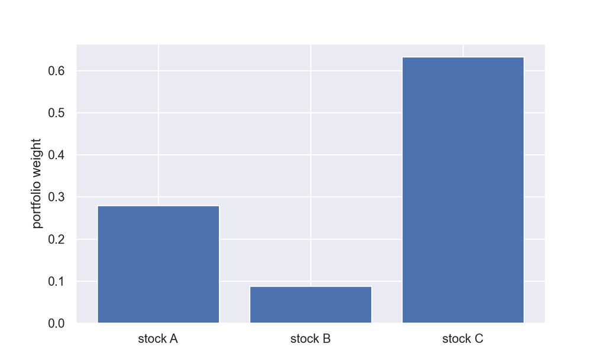

```python
import riskparityportfolio as rpp  # pip install riskparityportfolio (dependencies: numpy, jax, quadprog, pybind, and tqdm)
import numpy as np
import matplotlib.pyplot as plt

cov_matrix = np.vstack((np.array((1.0000, 0.0015, -0.0119)),
                        np.array((0.0015, 1.0000, -0.0308)),
                        np.array((-0.0119, -0.0308, 1.0000))))
risk_budget_vector = np.array((0.1594, 0.0126, 0.8280))
w = rpp.vanilla.design(cov_matrix, risk_budget_vector)
plt.bar(["stock " + item for item in ["A", "B", "C"]], w)
#> <BarContainer object of 3 artists>
plt.xlabel("")
plt.ylabel("portfolio weight")
plt.show()
```

# Python Scripts and Jupyter Notebooks

### Python Scripts

One simple way to use Python is by typing the commands in the IPython terminal one by one. However, this quickly becomes unscalable and it is necessary to write scripts. You can use your favourite text editor to create Python scripts.

### Jupyter Notebook/Lab

[Jupyter Notebook](https://jupyter.readthedocs.io/en/latest/) is a very powerful tool that enables you write report-like documents containing code, documentation, mathematical equations, figures, and so on.

# To explore further

Check out [Awesome Quant](https://github.com/wilsonfreitas/awesome-quant) for a list of curated packages relevant to financial applications.